# Untitled

João Victor

2022-10-22

Although the regression was made on my own, most of the pre processing data and EDA was based on this work: https://www.kaggle.com/code/erikbruin/house-prices-lasso-xgboost-and-a-detailed-eda

```r
library(tidyverse)
```

```r
library(corrplot)
library(plyr)
library(gridExtra)
library(caret)
library(mltools)
library(ggrepel)
library(car)
library(glmnet)
library(caTools)
library(e1071)
library(knitr)
library(Metrics)
```

### Read the Data Sets

```r
train = read.csv('train.csv')
test = read.csv('test.csv')
```

##### Remove Id Variable

```r
test$Id = NULL
train$Id = NULL
```

##### Merge the train and test data set

```r
test$SalePrice = NA
train_x = rbind(train, test)
```

##### SalePrice Histogram

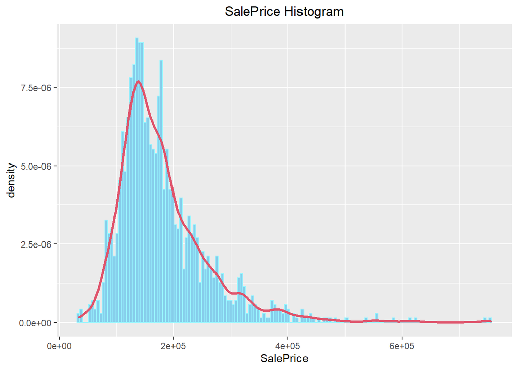

```r
ggplot(train_x[!is.na(train_x$SalePrice), ], aes(SalePrice)) +
  geom_histogram(aes(y = ..density..), bins = 150, colour = 'cadetblue1', fill = 'skyblue') +
  geom_density(lwd = 1.2, linetype = 1, colour = 2) +
  ggtitle('SalePrice Histogram') + theme(plot.title = element_text(hjust = 0.5))
```

##### Correlation Matrix

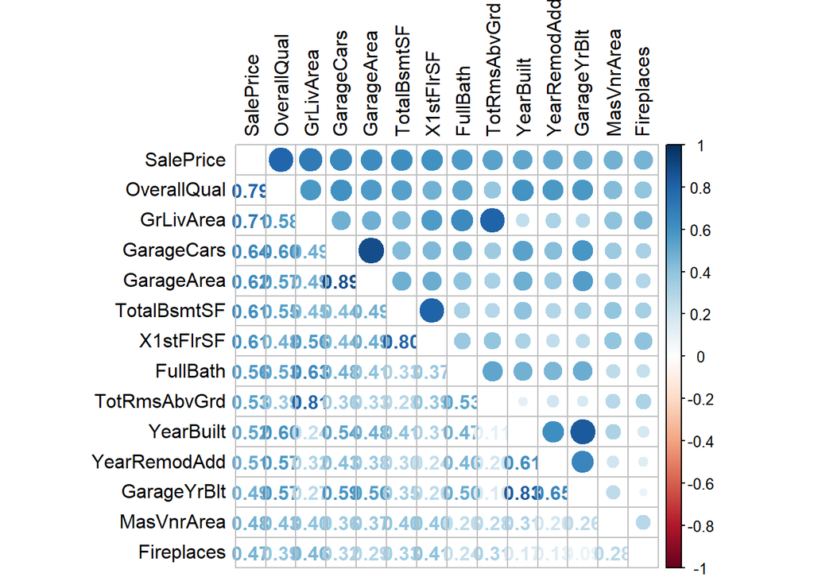

```r
numericVars = which(sapply(train_x, is.numeric))
numericVarNames = names(numericVars)

train_x_numVars = train_x[, numericVars]
cor_numVars = cor(train_x_numVars, use = 'pairwise.complete.obs')

cor_sorted = as.matrix(sort(cor_numVars[, 'SalePrice'], decreasing = T))

CorHigh = names(which(apply(cor_sorted, 1, function(x) abs(x) > 0.4)))
cor_numVars = cor_numVars[CorHigh, CorHigh]
corrplot.mixed(cor_numVars, tl.col = 'black', tl.pos = 'lt', )
```

##### SalePrice Boxplot

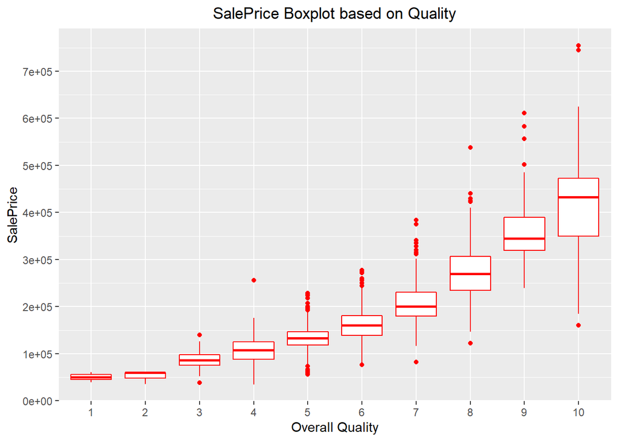

```r
ggplot(train_x[!is.na(train_x$SalePrice), ], aes(x = factor(OverallQual), y = SalePrice)) +
  geom_boxplot(col = 'red') + labs(x = 'Overall Quality') +
  scale_y_continuous(breaks = seq(0, 800000, by = 100000)) +
  ggtitle('SalePrice Boxplot based on Quality') + theme(plot.title = element_text(hjust = 0.5))
```

##### SalePrice vs GrLivArea Scatter Plot

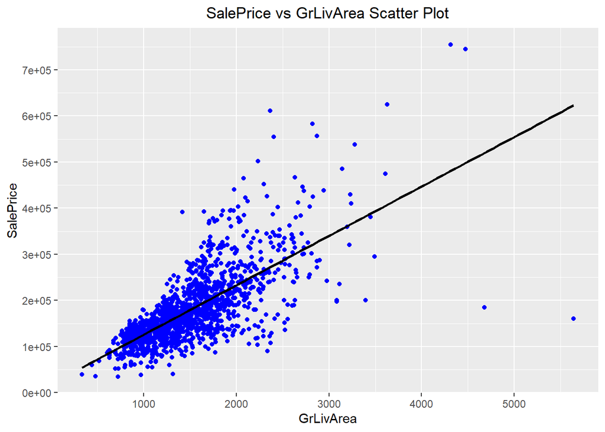

```r
ggplot(train_x, aes(x = GrLivArea, y = SalePrice)) +
  geom_point(col = 'blue') + geom_smooth(method = 'lm', se = F, color = 'black', aes(group = 1)) +
  scale_y_continuous(breaks = seq(0, 800000, by = 100000)) +
  ggtitle('SalePrice vs GrLivArea Scatter Plot') + theme(plot.title = element_text(hjust = 0.5))
```

##### Checking for missing values

```r
NAcol = colnames(train_x)[colSums(is.na(train_x)) > 0]
sort(colSums(sapply(train_x[NAcol], is.na)), decreasing = T)
```

```
##       PoolQC  MiscFeature        Alley        Fence    SalePrice  FireplaceQu
##         2909         2814         2721         2348         1459         1420
##  LotFrontage  GarageYrBlt GarageFinish   GarageQual   GarageCond   GarageType
##          486          159          159          159          159          157
##     BsmtCond BsmtExposure     BsmtQual BsmtFinType2 BsmtFinType1   MasVnrType
##           82           82           81           80           79           24
##   MasVnrArea     MSZoning    Utilities BsmtFullBath BsmtHalfBath   Functional
##           23            4            2            2            2            2
##  Exterior1st  Exterior2nd   BsmtFinSF1   BsmtFinSF2    BsmtUnfSF  TotalBsmtSF
##            1            1            1            1            1            1
##   Electrical  KitchenQual   GarageCars   GarageArea     SaleType
##            1            1            1            1            1
```

##### Fixing it

```r
#PoolQC
train_x$PoolQC[is.na(train_x$PoolQC)] = 'No Pool'

#MiscFeature
train_x$MiscFeature[is.na(train_x$MiscFeature)] = 'None'

#Alley
train_x$Alley[is.na(train_x$Alley)] = 'No Alley'

#Fence
train_x$Fence[is.na(train_x$Fence)] = 'No Fence'

#FireplaceQu
train_x$FireplaceQu[is.na(train_x$FireplaceQu)] = 'No Fireplace'

#LotFrontage
train_x$LotFrontage[is.na(train_x$LotFrontage)] = median(train_x$LotFrontage, na.rm = T)

#GarageType, GarageFinish, GarageQual, GarageCond
train_x = train_x %>%
  mutate_at(c('GarageType', 'GarageFinish', 'GarageQual', 'GarageCond'), ~replace_na(., 'No Garage'))

#GarageYrBlt
train_x$GarageYrBlt[is.na(train_x$GarageYrBlt)] = train_x$YearBuilt[is.na(train_x$GarageYrBlt)]
train_x[train_x$GarageYrBlt == 2207, ]$GarageYrBlt = 2007

#BsmtQual, BsmtCond, BsmtExposure, BsmtFinType1, BsmtFinType2
train_x = train_x %>%
  mutate_at(c('BsmtQual', 'BsmtCond', 'BsmtExposure', 'BsmtFinType1', 'BsmtFinType2'), ~replace_na(., 'No Basement'))

#MasVnrType
train_x$MasVnrType[is.na(train_x$MasVnrType)] = 'None'

#MasVnrArea
train_x$MasVnrArea[is.na(train_x$MasVnrArea)] = median(train_x$MasVnrArea, na.rm = T)

#Electrical
train_x$Electrical[is.na(train_x$Electrical)] = 'SBrkr'

#MSZoning
train_x$MSZoning[is.na(train_x$MSZoning)] = median(train_x$MSZoning, na.rm = T)

#BsmtFullBath
train_x$BsmtFullBath[is.na(train_x$BsmtFullBath)] = median(train_x$BsmtFullBath, na.rm = T)

#BsmtHalfBath
train_x$BsmtHalfBath[is.na(train_x$BsmtHalfBath)] = median(train_x$BsmtHalfBath, na.rm = T)

#Functional
train_x$Functional[is.na(train_x$Functional)] = median(train_x$Functional, na.rm = T)

#Exterior1st
train_x$Exterior1st[is.na(train_x$Exterior1st)] = names(sort(-table(train_x$Exterior1st))) [1]

#Exterior2nd
train_x$Exterior2nd[is.na(train_x$Exterior2nd)] = names(sort(-table(train_x$Exterior2nd))) [1]

#BsmtFinSF1
train_x$BsmtFinSF1[is.na(train_x$BsmtFinSF1)] = 0

#BsmtFinSF2
train_x$BsmtFinSF2[is.na(train_x$BsmtFinSF2)] = 0

#BsmtUnfSF
train_x$BsmtUnfSF[is.na(train_x$BsmtUnfSF)] = 0

#TotalBsmtSF
train_x$TotalBsmtSF[is.na(train_x$TotalBsmtSF)] = 0

#KitchenQual
train_x$KitchenQual[is.na(train_x$KitchenQual)] = 'TA' #replace with most common value

#GarageCars
train_x$GarageCars[is.na(train_x$GarageCars)] = 0

#GarageArea
train_x$GarageArea[is.na(train_x$GarageArea)] = 0

#SaleType
train_x$SaleType[is.na(train_x$SaleType)] = names(sort(-table(train_x$SaleType)))[1]
```

##### Check NA values again

```r
colnames(train_x)[colSums(is.na(train_x)) > 0]
```

```
## [1] "Utilities" "SalePrice"
```

```r
## Drop Utilities
train_x$Utilities = NULL
```

##### Create House Variables

```r
train_x$Remod = as.factor(ifelse(train_x$YearBuilt == train_x$YearRemodAdd, 0, 1)) #0 = No remodeling, 1 = Remodeling
train_x$IsNew <- as.factor(ifelse(train_x$YrSold == train_x$YearBuilt, 1, 0)) #0 = No, 1 = Yes
```

##### Converting Character Variables to Factor

```r
str(train_x)
```

```
## 'data.frame':    2919 obs. of  81 variables:
##  $ MSSubClass   : int  60 20 60 70 60 50 20 60 50 190 ...
##  $ MSZoning     : chr  "RL" "RL" "RL" "RL" ...
##  $ LotFrontage  : int  65 80 68 60 84 85 75 68 51 50 ...
##  $ LotArea      : int  8450 9600 11250 9550 14260 14115 10084 10382 6120 7420 ...
##  $ Street       : chr  "Pave" "Pave" "Pave" "Pave" ...
##  $ Alley        : chr  "No Alley" "No Alley" "No Alley" "No Alley" ...
##  $ LotShape     : chr  "Reg" "Reg" "IR1" "IR1" ...
##  $ LandContour  : chr  "Lvl" "Lvl" "Lvl" "Lvl" ...
##  $ LotConfig    : chr  "Inside" "FR2" "Inside" "Corner" ...
##  $ LandSlope    : chr  "Gtl" "Gtl" "Gtl" "Gtl" ...
##  $ Neighborhood : chr  "CollgCr" "Veenker" "CollgCr" "Crawfor" ...
##  $ Condition1   : chr  "Norm" "Feedr" "Norm" "Norm" ...
##  $ Condition2   : chr  "Norm" "Norm" "Norm" "Norm" ...
##  $ BldgType     : chr  "1Fam" "1Fam" "1Fam" "1Fam" ...
```

[output cut: 67 more lines]

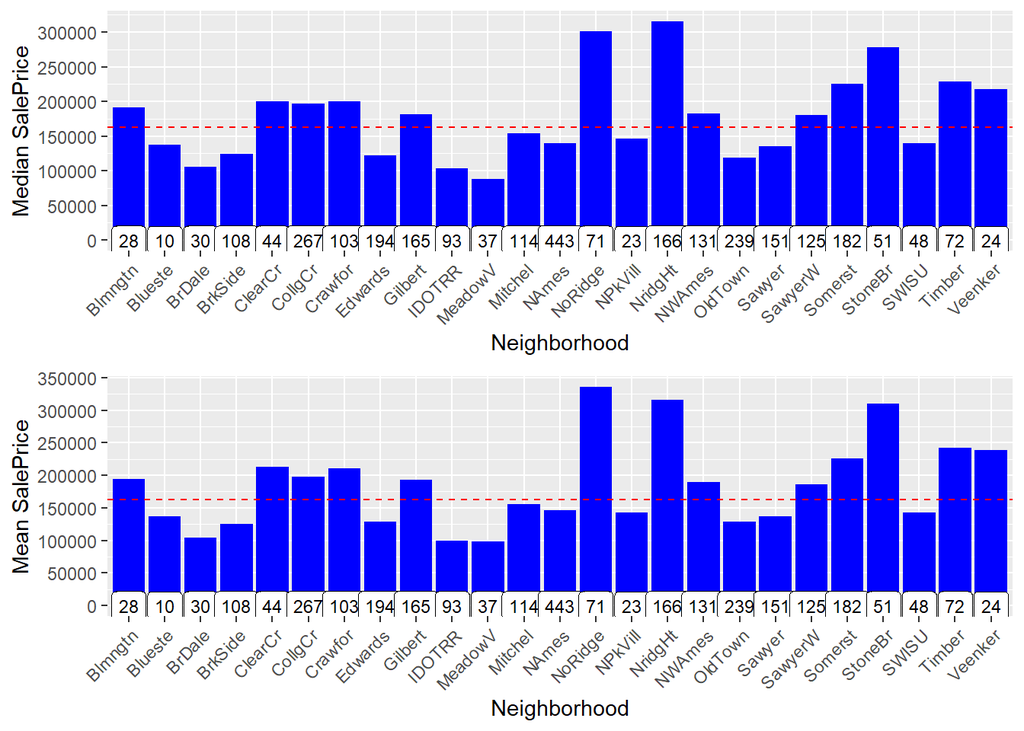

```r
## MSSubClass
train_x$MSSubClass = factor(train_x$MSSubClass, levels = c('20', '30', '40', '45', '50', '60', '70', '75', '80', '85', '90',
                                                           '120', '150', '160', '180', '190'),
                            labels = c(0, 1, 2, 3, 4, 5, 6, 7, 8, 9, 10, 11, 12, 13, 14, 15))

##MSZoning
train_x$MSZoning = factor(train_x$MSZoning, levels = c('C (all)', 'RM', 'RL', 'RH', 'FV'),
                          labels = c(0, 1, 2, 3, 4))

##Street
train_x$Street = factor(train_x$Street, levels = c('Pave', 'Grvl'), labels = c(0, 1))

##Alley
train_x$Alley = factor(train_x$Alley, levels = c('No Alley', 'Pave', 'Grvl'), labels =c(0, 1, 2))

##LotShape
train_x$LotShape = factor(train_x$LotShape, levels = c('IR3', 'IR2', 'IR1', 'Reg'), labels = c(0, 1, 2, 3))

##LandContour
train_x$LandContour = factor(train_x$LandContour, levels = c('Low', 'HLS', 'Bnk', 'Lvl'),
                             labels = c(0, 1, 2, 3))

##LotConfig
train_x$LotConfig = factor(train_x$LotConfig, levels = c('FR3', 'FR2', 'CulDSac', 'Corner', 'Inside'),
                           labels = c(0, 1, 2, 3, 4))

##LandSlope
train_x$LandSlope = factor(train_x$LandSlope, levels = c('Sev', 'Mod', 'Gtl'),
                           labels = c(0, 1, 2))

##Neighborhood
#Check where is the better Neighborhood
nb1 <- ggplot(train_x, aes(x=reorder(Neighborhood, SalePrice, FUN=median), y=SalePrice)) +
  geom_bar(stat='summary', fun = "median", fill='blue') + labs(x='Neighborhood', y='Median SalePrice') +
  theme(axis.text.x = element_text(angle = 45, hjust = 1)) +
  scale_y_continuous(breaks= seq(0, 800000, by=50000)) +
  geom_label(stat = "count", aes(label = ..count.., y = ..count..), size=3) +
  geom_hline(yintercept=163000, linetype="dashed", color = "red") #dashed line is median SalePrice

nb2 <- ggplot(train_x, aes(x=reorder(Neighborhood, SalePrice, FUN=mean), y=SalePrice)) +
  geom_bar(stat='summary', fun = "mean", fill='blue') + labs(x='Neighborhood', y="Mean SalePrice") +
  theme(axis.text.x = element_text(angle = 45, hjust = 1)) +
  scale_y_continuous(breaks= seq(0, 800000, by=50000)) +
  geom_label(stat = "count", aes(label = ..count.., y = ..count..), size=3) +
  geom_hline(yintercept=163000, linetype="dashed", color = "red") #dashed line is median SalePrice

grid.arrange(nb1, nb2)
```

```r
##Create NeighRich
train_x$NeighRich[train_x$Neighborhood %in% c('StoneBr', 'NridgHt', 'NoRidge')] = 2
train_x$NeighRich[!train_x$Neighborhood %in% c('MeadowV', 'IDOTRR', 'BrDale', 'StoneBr', 'NridgHt', 'NoRidge')] = 1
train_x$NeighRich[train_x$Neighborhood %in% c('MeadowV', 'IDOTRR', 'BrDale')] = 0
train_x$NeighRich = as.factor(train_x$NeighRich)

#train_x$Neighborhood = factor(train_x$Neighborhood, levels = c('Veenker', 'Timber', 'StoneBr', 'Somerst', 'SawyerW', 'Sawyer',
#                                                               'SWISU', 'OldTown', 'NWAmes', 'NridgHt', 'NPkVill', 'NoRidge',
#                                                               'NAmes', 'Mitchel', 'MeadowV', 'IDOTRR', 'Gilbert', 'Edwards',
#                                                               'Crawfor', 'CollgCr', 'ClearCr', 'BrkSide', 'BrDale', 'Blueste', 'Blmngtn' ),
#                              labels = c(0, 1, 2, 3, 4, 5, 6, 7, 8, 9, 10, 11, 12, 13, 14, 15, 16, 17, 18, 19, 20, 21, 22, 23, 24))

##Remove Neighborhood
train_x$Neighborhood = NULL

##Condition1
train_x$Condition1 = factor(train_x$Condition1, levels = c('RRAe', 'RRNe', 'PosA', 'PosN', 'RRAn', 'RRNn', 'Norm', 'Feedr', 'Artery'),
                            labels = c(0, 1, 2, 3, 4, 5, 6, 7, 8))

##Condition2
train_x$Condition2 = factor(train_x$Condition2, levels = c('RRAe', 'RRNe', 'PosA', 'PosN', 'RRAn', 'RRNn', 'Norm', 'Feedr', 'Artery'),
                            labels = c(0, 1, 2, 3, 4, 5, 6, 7, 8))

##BldgType
train_x$BldgType = factor(train_x$BldgType, levels = c('Twnhs', 'TwnhsE', 'Duplex', '2fmCon', '1Fam'),
                          labels = c(0, 1, 2, 3, 4))

##HouseStyle
train_x$HouseStyle = factor(train_x$HouseStyle, levels = c('SLvl', 'SFoyer', '2.5Unf', '2.5Fin', '2Story', '1.5Unf', '1.5Fin', '1Story'),
                            labels = c(0, 1, 2, 3, 4, 5, 6, 7))

##RoofStyle
train_x$RoofStyle = factor(train_x$RoofStyle, levels = c('Shed', 'Mansard', 'Hip', 'Gambrel', 'Gable', 'Flat'),
                           labels = c(0, 1, 2, 3, 4, 5))

##RoofMatl
train_x$RoofMatl = factor(train_x$RoofMatl, levels = c('WdShngl', 'WdShake', 'Tar&Grv', 'Roll', 'Metal', 'Membran', 'CompShg', 'ClyTile'),
                          labels = c(0, 1, 2, 3, 4, 5, 6, 7))

##Exterior1st
train_x$Exterior1st = factor(train_x$Exterior1st, levels = c('WdShing', 'Wd Sdng', 'VinylSd', 'Stucco', 'Stone', 'PreCast',
                                                             'Plywood', 'Other', 'MetalSd', 'ImStucc', 'HdBoard', 'CemntBd',
                                                             'CBlock', 'BrkFace', 'BrkComm', 'AsphShn', 'AsbShng'),
                             labels = c(0, 1, 2, 3, 4, 5, 6, 7, 8, 9, 10, 11, 12, 13, 14, 15, 16))

##Exterior2nd
train_x$Exterior2nd = factor(train_x$Exterior2nd, levels = c('Wd Shng', 'Wd Sdng', 'VinylSd', 'Stucco', 'Stone', 'PreCast',
                                                             'Plywood', 'Other', 'MetalSd', 'ImStucc', 'HdBoard', 'CmentBd',
                                                             'CBlock', 'BrkFace', 'Brk Cmn', 'AsphShn', 'AsbShng'),
                             labels = c(0, 1, 2, 3, 4, 5, 6, 7, 8, 9, 10, 11, 12, 13, 14, 15, 16))

##MasVnrType
train_x$MasVnrType = factor(train_x$MasVnrType, levels = c('Stone', 'None', 'CBlock', 'BrkFace', 'BrkCmn'),
                            labels = c(0, 1, 2, 3, 4))

##ExterQual
train_x$ExterQual = factor(train_x$ExterQual, levels = c('Po', 'Fa', 'TA', 'Gd', 'Ex'),
                           labels = c(0, 1, 2, 3, 4))

##ExterCond
train_x$ExterCond = factor(train_x$ExterCond, levels = c('Po', 'Fa', 'TA', 'Gd', 'Ex'),
                           labels = c(0, 1, 2, 3, 4))

##Foundation
train_x$Foundation = factor(train_x$Foundation, levels = c('Wood', 'Stone', 'Slab', 'PConc', 'CBlock', 'BrkTil'),
                            labels = c(0, 1, 2, 3, 4, 5))

##BsmtQual
train_x$BsmtQual = factor(train_x$BsmtQual, levels = c('No Basement', 'Po', 'Fa', 'TA', 'Gd', 'Ex'),
                          labels = c(0, 1, 2, 3, 4, 5))

##BsmtCond
train_x$BsmtCond = factor(train_x$BsmtCond, levels = c('No Basement', 'Po','Fa', 'TA', 'Gd', 'Ex'),
                          labels = c(0, 1, 2, 3, 4, 5))

##BsmtExposure
train_x$BsmtExposure = factor(train_x$BsmtExposure, levels = c('No Basement', 'No', 'Mn', 'Av', 'Gd'),
                              labels = c(0, 1, 2, 3, 4))

##BsmtFinType1
train_x$BsmtFinType1 = factor(train_x$BsmtFinType1, levels = c('No Basement', 'Unf', 'LwQ', 'Rec', 'BLQ', 'ALQ', 'GLQ'),
                              labels = c(0, 1, 2, 3, 4, 5, 6))

##BsmtFinType2
train_x$BsmtFinType2 = factor(train_x$BsmtFinType2, levels = c('No Basement', 'Unf', 'LwQ', 'Rec', 'BLQ', 'ALQ', 'GLQ'),
                              labels = c(0, 1, 2, 3, 4, 5, 6))

##Heating
train_x$Heating = factor(train_x$Heating, levels = c('Wall', 'OthW', 'Grav', 'GasW', 'GasA', 'Floor'),
                         labels = c(0, 1, 2, 3, 4, 5))

##HeatingQC
train_x$HeatingQC = factor(train_x$HeatingQC, levels = c('Po', 'Fa', 'TA', 'Gd', 'Ex'),
                           labels = c(0, 1, 2, 3, 4))

##CentralAir
train_x$CentralAir = factor(train_x$CentralAir, levels = c('N', 'Y'),
                            labels = c(0, 1))

##Electrical
train_x$Electrical = factor(train_x$Electrical, levels = c('Mix', 'FuseP', 'FuseF', 'FuseA', 'SBrkr'),
                            labels = c(0, 1, 2, 3, 4))

##KitchenQual
train_x$KitchenQual = factor(train_x$KitchenQual, levels = c('Po', 'Fa', 'TA', 'Gd', 'Ex'),
                             labels = c(0, 1, 2, 3, 4))

##Functional
train_x$Functional = factor(train_x$Functional, levels = c('Sal', 'Sev', 'Maj2', 'Maj1', 'Mod', 'Min2', 'Min1', 'Typ'),
                            labels = c(0, 1, 2, 3, 4, 5, 6, 7))

##FireplaceQu
train_x$FireplaceQu = factor(train_x$FireplaceQu, levels = c('No Fireplace', 'Po', 'Fa', 'TA', 'Gd', 'Ex'),
                             labels = c(0, 1, 2, 3, 4, 5))

##GarageType
train_x$GarageType = factor(train_x$GarageType, levels = c('No Garage', 'Detchd', 'CarPort', 'BuiltIn', 'Basment', 'Attchd', '2Types'),
                            labels = c(0, 1, 2, 3, 4, 5, 6))

##GarageFinish
train_x$GarageFinish = factor(train_x$GarageFinish, levels = c('No Garage', 'Unf', 'RFn', 'Fin'),
                             labels = c(0, 1, 2, 3))

##GarageQual
train_x$GarageQual = factor(train_x$GarageQual, levels = c('No Garage', 'Po', 'Fa', 'TA', 'Gd', 'Ex'),
                            labels = c(0, 1, 2, 3, 4, 5))

##GarageCond
train_x$GarageCond = factor(train_x$GarageCond, levels = c('No Garage', 'Po', 'Fa', 'TA', 'Gd', 'Ex'),
                            labels = c(0, 1, 2, 3, 4, 5))

##PavedDrive
train_x$PavedDrive = factor(train_x$PavedDrive, levels = c('N', 'P', 'Y'),
                            labels = c(0, 1, 2))

##PoolQC
train_x$PoolQC = factor(train_x$PoolQC, levels = c('No Pool', 'Fa', 'TA', 'Gd', 'Ex'),
                        labels = c(0, 1, 2, 3, 4))

##Fence
train_x$Fence = factor(train_x$Fence, levels = c('No Fence', 'MnWw', 'GdWo', 'MnPrv', 'GdPrv'),
                       labels = c(0, 1, 2, 3, 4))

##MiscFeature
train_x$MiscFeature = factor(train_x$MiscFeature, levels = c('None', 'TenC', 'Shed', 'Othr', 'Gar2', 'Elev'),
                             labels = c(0, 1, 2, 3, 4, 5))

##SaleType
train_x$SaleType = factor(train_x$SaleType, levels = c('Oth', 'ConLD', 'ConLI', 'ConLw', 'Con', 'COD', 'New', 'VWD', 'CWD', 'WD'),
                          labels = c(0, 1, 2, 3, 4, 5, 6, 7, 8, 9))

##SaleCondition
train_x$SaleCondition = factor(train_x$SaleCondition, levels = c('Partial', 'Family', 'Alloca', 'AdjLand', 'Abnorml', 'Normal'),
                               labels = c(0, 1, 2, 3, 4, 5))
```

##### Check Again

```r
str(train_x)
```

```
## 'data.frame':    2919 obs. of  81 variables:
##  $ MSSubClass   : Factor w/ 16 levels "0","1","2","3",..: 6 1 6 7 6 5 1 6 5 16 ...
##  $ MSZoning     : Factor w/ 5 levels "0","1","2","3",..: 3 3 3 3 3 3 3 3 2 3 ...
##  $ LotFrontage  : int  65 80 68 60 84 85 75 68 51 50 ...
##  $ LotArea      : int  8450 9600 11250 9550 14260 14115 10084 10382 6120 7420 ...
##  $ Street       : Factor w/ 2 levels "0","1": 1 1 1 1 1 1 1 1 1 1 ...
##  $ Alley        : Factor w/ 3 levels "0","1","2": 1 1 1 1 1 1 1 1 1 1 ...
##  $ LotShape     : Factor w/ 4 levels "0","1","2","3": 4 4 3 3 3 3 4 3 4 4 ...
##  $ LandContour  : Factor w/ 4 levels "0","1","2","3": 4 4 4 4 4 4 4 4 4 4 ...
##  $ LotConfig    : Factor w/ 5 levels "0","1","2","3",..: 5 2 5 4 2 5 5 4 5 4 ...
##  $ LandSlope    : Factor w/ 3 levels "0","1","2": 3 3 3 3 3 3 3 3 3 3 ...
##  $ Condition1   : Factor w/ 9 levels "0","1","2","3",..: 7 8 7 7 7 7 7 4 9 9 ...
##  $ Condition2   : Factor w/ 9 levels "0","1","2","3",..: 7 7 7 7 7 7 7 7 7 9 ...
##  $ BldgType     : Factor w/ 5 levels "0","1","2","3",..: 5 5 5 5 5 5 5 5 5 4 ...
##  $ HouseStyle   : Factor w/ 8 levels "0","1","2","3",..: 5 8 5 5 5 7 8 5 7 6 ...
```

[output cut: 67 more lines]

```r
colnames(train_x)[colSums(is.na(train_x)) > 0]
```

```
## [1] "SalePrice"
```

##### Converting some Numeric Variables to Factor

```r
##OverallQual
train_x$OverallQual = as.factor(train_x$OverallQual)

##OverallCond
train_x$OverallCond = as.factor(train_x$OverallCond)

##BsmtFullBath
train_x$BsmtFullBath = as.factor(train_x$BsmtFullBath)

##BsmtHalfBath
train_x$BsmtHalfBath = as.factor(train_x$BsmtHalfBath)

##FullBath
train_x$FullBath = as.factor(train_x$FullBath)

##HalfBath
train_x$HalfBath = as.factor(train_x$HalfBath)

##BedroomAbvGr
train_x$BedroomAbvGr = as.factor(train_x$BedroomAbvGr)

##KitchenAbvGr
train_x$KitchenAbvGr = as.factor(train_x$KitchenAbvGr)

##TotRmsAbvGrd
train_x$TotRmsAbvGrd = as.factor(train_x$TotRmsAbvGrd)

##Fireplaces
train_x$Fireplaces = as.factor(train_x$Fireplaces)

##GarageCars
train_x$GarageCars = as.factor(train_x$GarageCars)
```

##### Structure of the Data again

```r
str(train_x)
```

```
## 'data.frame':    2919 obs. of  81 variables:
##  $ MSSubClass   : Factor w/ 16 levels "0","1","2","3",..: 6 1 6 7 6 5 1 6 5 16 ...
##  $ MSZoning     : Factor w/ 5 levels "0","1","2","3",..: 3 3 3 3 3 3 3 3 2 3 ...
##  $ LotFrontage  : int  65 80 68 60 84 85 75 68 51 50 ...
##  $ LotArea      : int  8450 9600 11250 9550 14260 14115 10084 10382 6120 7420 ...
##  $ Street       : Factor w/ 2 levels "0","1": 1 1 1 1 1 1 1 1 1 1 ...
##  $ Alley        : Factor w/ 3 levels "0","1","2": 1 1 1 1 1 1 1 1 1 1 ...
##  $ LotShape     : Factor w/ 4 levels "0","1","2","3": 4 4 3 3 3 3 4 3 4 4 ...
##  $ LandContour  : Factor w/ 4 levels "0","1","2","3": 4 4 4 4 4 4 4 4 4 4 ...
##  $ LotConfig    : Factor w/ 5 levels "0","1","2","3",..: 5 2 5 4 2 5 5 4 5 4 ...
##  $ LandSlope    : Factor w/ 3 levels "0","1","2": 3 3 3 3 3 3 3 3 3 3 ...
##  $ Condition1   : Factor w/ 9 levels "0","1","2","3",..: 7 8 7 7 7 7 7 4 9 9 ...
##  $ Condition2   : Factor w/ 9 levels "0","1","2","3",..: 7 7 7 7 7 7 7 7 7 9 ...
##  $ BldgType     : Factor w/ 5 levels "0","1","2","3",..: 5 5 5 5 5 5 5 5 5 4 ...
##  $ HouseStyle   : Factor w/ 8 levels "0","1","2","3",..: 5 8 5 5 5 7 8 5 7 6 ...
```

[output cut: 67 more lines]

##### Scale the variables

```r
scaling = train_x %>% select(LotFrontage, LotArea, MasVnrArea, BsmtFinSF1, BsmtFinSF2,BsmtUnfSF, TotalBsmtSF, X1stFlrSF, X2ndFlrSF,
                             LowQualFinSF, GrLivArea, GarageArea, WoodDeckSF, OpenPorchSF, EnclosedPorch, X3SsnPorch, ScreenPorch,
                             PoolArea, MiscVal)

PreNum = preProcess(scaling, method = c('center', 'scale'))
print(PreNum)
```

```
## Created from 2919 samples and 19 variables
##
## Pre-processing:
##   - centered (19)
##   - ignored (0)
##   - scaled (19)
```

```r
train_x = predict(PreNum, train_x)
dim(train_x)
```

```
## [1] 2919   81
```

```r
numVars = which(sapply(train_x, is.numeric))
factorVars = which(sapply(train_x, is.factor))

cat('There are', length(numVars), 'numeric variables, and', length(factorVars), 'factor variables')
```

```
## There are 25 numeric variables, and 56 factor variables
```

##### Second Correlation Matrix

```r
matrix = model.matrix(~0+., data = train_x) %>%
  cor(use = 'pairwise.complete.obs')
```

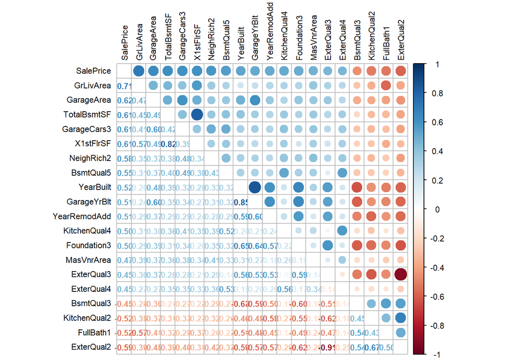

```r
matrix_sorted = as.matrix(sort(matrix[, 'SalePrice'], decreasing = T))
MatrixHigh = names(which(apply(matrix_sorted, 1, function(x) abs(x)>0.45)))
cor_factor = matrix[MatrixHigh, MatrixHigh]
corrplot.mixed(cor_factor, tl.col = 'black', tl.pos = 'lt', tl.cex = 0.7, cl.cex = .7, number.cex = .7)
```

##### Drop Variables With Few Distinctions

```r
table(train_x$RoofMatl)
```

```
##
##    0    1    2    3    4    5    6    7
##    7    9   23    1    1    1 2876    1
```

```r
##DROP Street
train_x$Street = NULL

##DROP Condition2
train_x$Condition2 = NULL

##DROP RoofMatl
train_x$RoofMatl = NULL

##DROP Heating
train_x$Heating = NULL

##DROP LowQualFinSF
train_x$LowQualFinSF = NULL

##DROP X3SsnPorch
train_x$X3SsnPorch = NULL

#DROP PoolQC
train_x$PoolQC = NULL

#DROP PoolArea
train_x$PoolArea = NULL
```

### Plots

##### IsNew

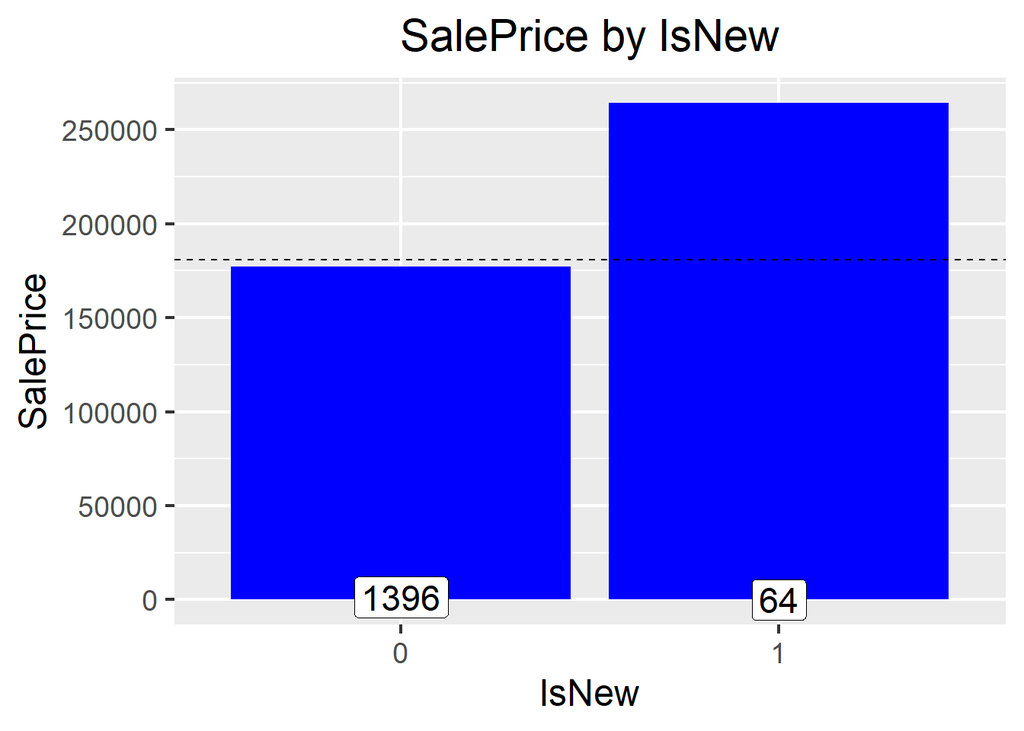

```r
#IsNew
ggplot(train_x[!is.na(train_x$SalePrice), ], aes(x=IsNew, y=SalePrice)) +
  geom_bar(stat = 'summary', fun ='mean', fill='blue') +
  geom_label(stat = "count", aes(label = ..count.., y = ..count..), size=6) +
  scale_y_continuous(breaks= seq(0, 800000, by=50000)) +
  theme_grey(base_size = 18) +
  geom_hline(yintercept=mean(train$SalePrice), linetype="dashed") +
  ggtitle('SalePrice by IsNew') + theme(plot.title = element_text(hjust = 0.5))
```

##### BldgType

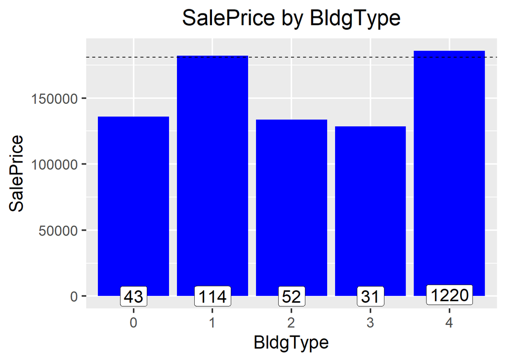

```r
ggplot(train_x[!is.na(train_x$SalePrice), ], aes(x=BldgType, y=SalePrice)) +
  geom_bar(stat = 'summary', fun ='mean', fill='blue') +
  geom_label(stat = "count", aes(label = ..count.., y = ..count..), size=6) +
  scale_y_continuous(breaks= seq(0, 800000, by=50000)) +
  theme_grey(base_size = 18) +
  geom_hline(yintercept=mean(train$SalePrice), linetype="dashed") +
  ggtitle('SalePrice by BldgType') + theme(plot.title = element_text(hjust = 0.5))
```

##### YearBuilt

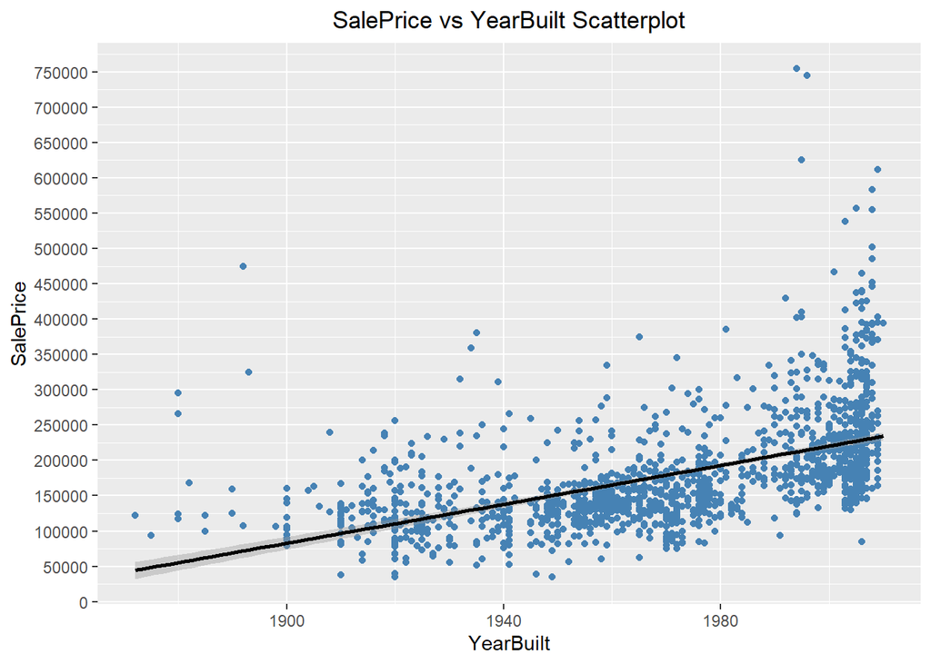

```r
ggplot(train_x[!is.na(train_x$SalePrice), ], aes(x=YearBuilt, y=SalePrice)) +
  geom_point(color = 'steelblue') + geom_smooth(method = 'lm', color = 'black') +
  scale_y_continuous(breaks= seq(0, 800000, by=50000)) +
  ggtitle('SalePrice vs YearBuilt Scatterplot') + theme(plot.title = element_text(hjust = 0.5))
```

Like the scatter plot suggests, new houses were sold by higher price then old houses.

##### TotRoomsAbvGrd

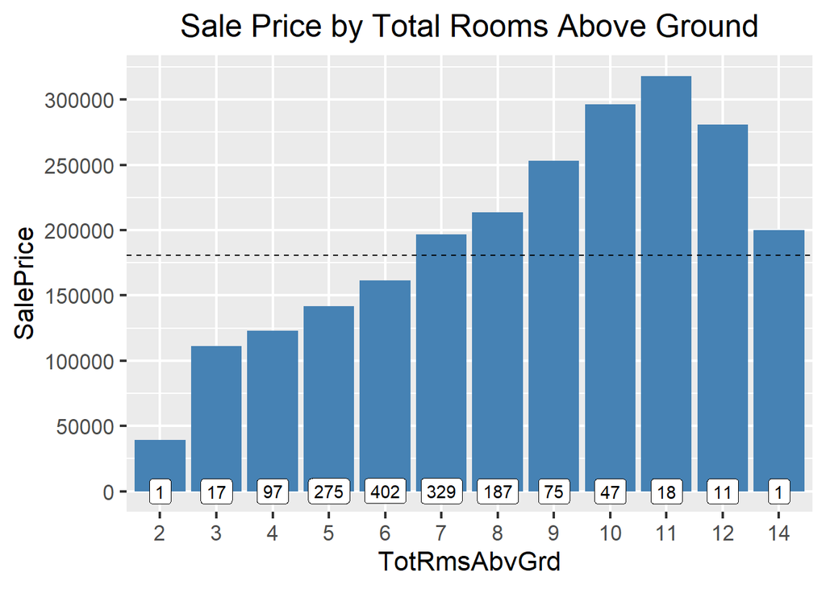

```r
ggplot(train_x[!is.na(train_x$SalePrice), ], aes(TotRmsAbvGrd, SalePrice)) +
  geom_bar(stat = 'summary', fun = 'mean', fill = 'steelblue') +
  geom_label(stat = 'count', aes(label = ..count.., y = ..count..)) +
  scale_y_continuous(breaks = seq(0, 350000, by = 50000)) +
  theme_grey(base_size = 16) +
  geom_hline(yintercept = mean(train$SalePrice), linetype = 'dashed') +
  ggtitle('Sale Price by Total Rooms Above Ground') + theme(plot.title = element_text(hjust = 0.5))
```

Houses with more rooms are more expensive. While houses with 3 rooms have a mean around 110000, houses with 11 rooms have a mean around 320000.

##### GrLivArea

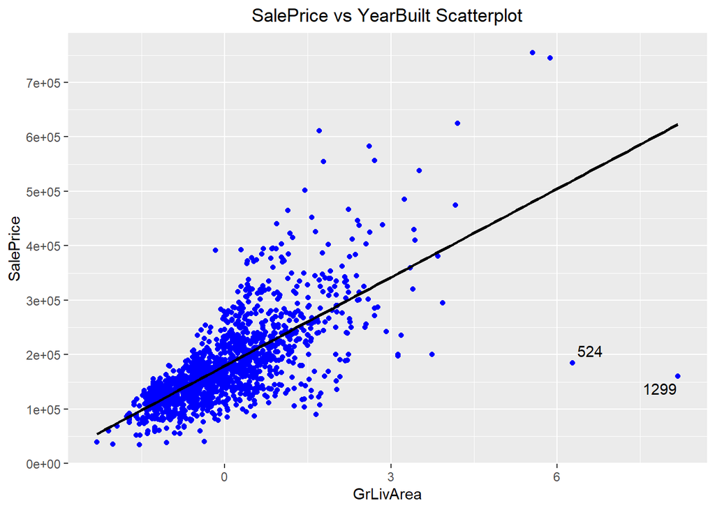

```r
ggplot(train_x[!is.na(train_x$SalePrice), ], aes(x=GrLivArea, y=SalePrice))+
  geom_point(col='blue') + geom_smooth(method = "lm", se=FALSE, color="black") +
  scale_y_continuous(breaks= seq(0, 800000, by=100000)) +
  geom_text_repel(aes(label = ifelse(GrLivArea > 6, rownames(train_x), ''))) +
  ggtitle('SalePrice vs YearBuilt Scatterplot') + theme(plot.title = element_text(hjust = 0.5))
```

This plot shows us that as long the ground live area increases, the sale price increases together. Just a reminder, GrLivArea is scaled, thats why the area have this tiny values. Furthermore, the graphic also shows us 2 outliers, even though there are only 2, outliers can have a greatly influence in the model.

##### Check variables in the data set

```r
numVars = which(sapply(train_x, is.numeric))
factorVars = which(sapply(train_x, is.factor))

cat('There are', length(numVars), 'numeric variables, and', length(factorVars), 'factor variables')
```

```
## There are 22 numeric variables, and 51 factor variables
```

### One Hot Encoding

```r
datafor_hot_names = names(factorVars)
data_hot = train_x[, datafor_hot_names]

dummies = dummyVars(" ~. ", data = data_hot)
dummies = data.frame(predict(dummies, newdata = data_hot))
```

After the One Hot Encoding, i choose to drop variables with less than 20 observations. The choice for 20 numbers was because, for example, one variable can have 13 observations in train set and 5 in test set, so i want that every variable have at least 10 observations, so i think 20 is a good number for that condition, although this method is not a savior and can have serious problems. Nothing prevent that a variable with 21 observations can have 19 in the train set and 2 in the test set.

```r
few = which(colSums(dummies[1:nrow(dummies), ], ) <= 20)
fewnames = names(few)
fewnames
```

```
##  [1] "MSSubClass.2"    "MSSubClass.3"    "MSSubClass.12"   "MSSubClass.14"
##  [5] "LotShape.0"      "LotConfig.0"     "LandSlope.0"     "Condition1.1"
##  [9] "Condition1.2"    "Condition1.5"    "HouseStyle.3"    "HouseStyle.5"
## [13] "OverallQual.1"   "OverallQual.2"   "OverallCond.1"   "OverallCond.2"
## [17] "RoofStyle.0"     "RoofStyle.1"     "RoofStyle.5"     "Exterior1st.4"
## [21] "Exterior1st.5"   "Exterior1st.7"   "Exterior1st.9"   "Exterior1st.12"
## [25] "Exterior1st.14"  "Exterior1st.15"  "Exterior2nd.4"   "Exterior2nd.5"
## [29] "Exterior2nd.7"   "Exterior2nd.9"   "Exterior2nd.12"  "Exterior2nd.15"
## [33] "MasVnrType.2"    "ExterQual.0"     "ExterCond.0"     "ExterCond.4"
## [37] "Foundation.0"    "Foundation.1"    "BsmtQual.1"      "BsmtCond.1"
## [41] "BsmtCond.5"      "HeatingQC.0"     "Electrical.0"    "Electrical.1"
## [45] "BsmtFullBath.3"  "BsmtHalfBath.2"  "FullBath.0"      "FullBath.4"
## [49] "BedroomAbvGr.0"  "BedroomAbvGr.8"  "KitchenAbvGr.0"  "KitchenAbvGr.3"
## [53] "KitchenQual.0"   "TotRmsAbvGrd.2"  "TotRmsAbvGrd.12" "TotRmsAbvGrd.13"
## [57] "TotRmsAbvGrd.14" "TotRmsAbvGrd.15" "Functional.0"    "Functional.1"
## [61] "Functional.2"    "Functional.3"    "Fireplaces.3"    "Fireplaces.4"
## [65] "GarageType.2"    "GarageCars.4"    "GarageCars.5"    "GarageQual.1"
## [69] "GarageQual.5"    "GarageCond.1"    "GarageCond.4"    "GarageCond.5"
## [73] "Fence.1"         "MiscFeature.1"   "MiscFeature.3"   "MiscFeature.4"
## [77] "MiscFeature.5"   "SaleType.0"      "SaleType.2"      "SaleType.3"
## [81] "SaleType.4"      "SaleType.7"      "SaleType.8"      "SaleCondition.3"
```

```r
#remove
dummies = dummies[, -few]

numericVarNames = names(numVars)
data_num = train_x[, numericVarNames]

final_data = cbind(dummies, data_num)
```

##### Split the set for Train and Test

```r
#Make Train and Test Set again
x.train = data.matrix(final_data[1:1460, 1:252])
x.test = data.matrix(final_data[1461:2919, 1:252])

y.train = final_data$SalePrice[1:1460]
```

##### Ridge Regression

```r
ridge.fit = cv.glmnet(x.train, y.train, type.measure = 'mse', alpha = 0, family = 'gaussian')

ridge.pred = predict(ridge.fit, s = ridge.fit$lambda.1se, newx = x.test)
```

##### Lasso Regression

```r
lasso.fit = cv.glmnet(x.train, y.train, type.measure = 'mse', alpha = 1, family = 'gaussian')

lasso.pred = predict(lasso.fit, s = lasso.fit$lambda.1se, newx = x.test)
```

##### Elastic Net Regression

```r
elastic.fit = cv.glmnet(x.train, y.train, type.measure = 'mse', alpha = 0.5, family = 'gaussian')

elastic.pred = predict(elastic.fit, s = elastic.fit$lambda.1se, newx = x.test)
```

##### Note

```r
knitr::opts_chunk$set(cache = T)
datasplit = final_data[1:1460, ]

sample = sample.split(datasplit$SalePrice, SplitRatio = 0.7)
train_for = subset(datasplit, sample == T)
test_for = subset(datasplit, sample == F)

x_train = data.matrix(train_for[, 1:252])
x_test = data.matrix(test_for[, 1:252])

y_train = train_for$SalePrice
y_test = test_for$SalePrice
```

##### Ridge

```r
alpha0.fit = cv.glmnet(x_train, y_train, type.measure = 'mse', alpha = 0, family = 'gaussian')

pred.alpha0 = predict(alpha0.fit, s = alpha0.fit$lambda.min, newx = x_test)
```

##### SSE and R<sup>2</sup>

```r
sst = sum((y_test - mean(y_test))^2)
sse.alpha0 = sum((pred.alpha0 - y_test)^2)
mean((y_test - pred.alpha0)^2)
```

```
## [1] 399286866
```

```r
#find R-Squared
rsq.alpha0 <- 1 - sse.alpha0/sst
rsq.alpha0
```

```
## [1] 0.8763
```

Ridge Regression model had a R<sup>2</sup> of 0.8763.

##### Lasso

```r
alpha1.fit = cv.glmnet(x_train, y_train, type.measure = 'mse', alpha = 1, family = 'gaussian')

pred.alpha1 = predict(alpha1.fit, s = alpha1.fit$lambda.min, newx = x_test)
```

##### SSE and R<sup>2</sup>

```r
sse.alpha1 = sum((pred.alpha1 - y_test)^2)
mean((y_test - pred.alpha1)^2)
```

```
## [1] 395427160
```

```r
#find R-Squared
rsq.alpha1 <- 1 - sse.alpha1/sst
rsq.alpha1
```

```
## [1] 0.8774957
```

Lasso Regression model had a R<sup>2</sup> of 0.8774.

##### Elastic Net

```r
alpha0.5.fit = cv.glmnet(x_train, y_train, type.measure = 'mse', alpha = 0.5, family = 'gaussian')

pred.alpha0.5 = predict(alpha0.5.fit, s = alpha0.5.fit$lambda.min, newx = x_test)
```

##### SSE and R<sup>2</sup>

```r
sse.alpha0.5 = sum((pred.alpha0.5 - y_test)^2)
mean((y_test - pred.alpha0.5)^2)
```

```
## [1] 397011211
```

```r
#find R-Squared
rsq.alpha0.5 <- 1 - sse.alpha0.5/sst
rsq.alpha0.5
```

```
## [1] 0.877005
```

Elastic Net Regression had a R<sup>2</sup> of 0.8770.

Ridge, Lasso and Elastic Net regressions get almost the same results. While I was testing the model and before the seed was settled, these three regressions were changing positions of the best model possible.

On the chunk below i will find the best alpha that i can put in the model.

##### Finding the best alpha

```r
list.of.fits = list()
for (i in 0:10) {
  model.name = paste0("alpha", i/10)

  list.of.fits[[model.name]] =
    cv.glmnet(x_train, y_train, type.measure = 'mse', alpha = i/10, family = 'gaussian')
}

results = data.frame()
for (i in 0:10) {
  model.name = paste0("alpha", i/10)

  predicted = predict(list.of.fits[[model.name]], s = list.of.fits[[model.name]]$lambda.min, newx = x_test)
  mse = mean((y_test - predicted)^2)
  temp = data.frame(alpha = i/10, mse = mse, model.name = model.name)
  results = rbind(results, temp)
}

results
```

```
##    alpha       mse model.name
## 1    0.0 395080134     alpha0
## 2    0.1 358061679   alpha0.1
## 3    0.2 365325430   alpha0.2
## 4    0.3 376072036   alpha0.3
## 5    0.4 377908069   alpha0.4
## 6    0.5 378676791   alpha0.5
## 7    0.6 380185903   alpha0.6
## 8    0.7 382169061   alpha0.7
## 9    0.8 382248435   alpha0.8
## 10   0.9 384081077   alpha0.9
## 11   1.0 384915746     alpha1
```

We can see that again, the MSE of the models were too close between them, but the best alpha was 0.1. It’s important to know that the results can change drastically depending on sample to sample. Some samples is easier to predict and get less MSE and some samples are harder to predict and your MSE will be high.

##### Linear Model

```r
linear.fit = lm(SalePrice ~., data = train_for)

pred.linear = predict(linear.fit, newdata = test_for)
sse.linear = sum((test_for$SalePrice - pred.linear)^2)
mean((test_for$SalePrice - pred.linear)^2)
```

```
## [1] 761899899
```

```r
sst.linear = sum((test_for$SalePrice - mean(test_for$SalePrice))^2)

rsq.linear = 1 - sse.linear/sst.linear
rsq.linear
```

```
## [1] 0.7639616
```

Linear Regression had a R<sup>2</sup> of 0.7639.

*Dataset:*https://www.kaggle.com/competitions/house-prices-advanced-regression-techniques/data